# Characteristics of Recent Mexican Immigrants to the US

Ben 10 October 27, 2019

```r
library(readr)
library(knitr)
library(tidyverse)
library(dplyr)
```

## Section 1. Introduction

In recent years, immigration has been a topic of intense controversy. Given the complexity of immigration law, we are interested in examining the experiences of immigrants since the beginning of the millenia. The U.S. stance on immigration has grown increasingly strict, not only for “illegal” immigration, but also for legal immigration: naturalization, visa use, lawful permanent residency, refugee status, and asylum seekers.

For example, the number of refugees accepted from all countries worldwide to the US fell to 22,491 in 2018 from 84,994 in 2016 according to the Department of State, likely as a result of hard line policies against refugees coming to the US. As immigration policies seem likely to tighten in the lead up to the 2020 elections, we are examining immigration to the US from Mexico and the characteristics of these immigrants.

Given the variety of ways to immigrate legally,and the widely varying experiences of immigrants from different backgrounds, we expect that the success of immigrants, measured in the form of annual income, to stem from their demographic differences and experiences of immigration.

Our research project aims to determine the characteristics of Mexican immigration to the US. We hypothesize that there exist statistically significant trends in Mexican immigrants to the US, and that we can determine where migrants are coming from, why and where they are going, as well as explore their experiences when they arrive.

## Section 2. Exploratory Data Analysis

```r
data <- read_csv("/cloud/project/02-data/dat.csv")
```

### Data Collection Method and Description

The dataset is from The Mexican Migration Project (MMP, *see References below for confidentiality terms). It was created in 1982 by an interdisciplinary team of researchers to further our understanding of the complex process of Mexican migration to the United States. The project is a binational research effort co-directed by Jorge Durand, professor of Social Anthropology at the University of Guadalajara (Mexico), and Douglas S. Massey, professor of Sociology and Public Affairs, with a joint appointment in the Woodrow Wilson School, at Princeton University (US).

Since its inception, the MMP’s main focus has been to gather social as well as economic information on Mexican-US migration. The data collected has been compiled in a comprehensive database that is available to the public free of charge for research and educational purposes through its web-site. The MMP uses the ethnosurvey approach to gather data: in winter months, they randomly sample households in communities throughout Mexico, surveying household heads and members about their first and last trip to the US, as well as economic and demographic information. They then conduct the same survey in destination areas in the US, sampling migrants from the same communities they survey in Mexico but who have not returned to Mexico. Thus, the sample of migrants includes residents in both Mexico and the US.

The MMP170 Database contains an initial file with general demographic, economic, and migratory information for each member of a surveyed household (PERS). Pers170 has 132 variables and 176701 observations,and hence it is very large. Therefore, we selected 17 meaningful variables and filtered out rows that contain N/A’s to create a new dataset labeled `data`.

The response variable we will be examining is `hhincome`, or household income. It is a numeric variable.

The predictors we will consider are sex (categorical), relhead (relationship to head of household, categorical), yrborn (year of birth, numeric), age (in years, numeric), statebrn (state of birth, categorical), marstat (marital status, categorical), edyrs (years of school completed, numeric), usstate1 (state of residence on first US migration, categorical), usstatel (state of residence on last US migration, categorical), uscity (city of residence on first US migration, categorical), usplacel (city of residence on last US migration, categorical), usdur1 (duration of first US migration in months, numeric), usdurl (duration of last US migration in months, numeric), usdoc1 (type of documentation used on first US migration, categorical), and occtype (category of occupation, categorical).

### Variable Cleaning and Recoding

“X1”: Number of observation

“sex”: Sex

“relhead”: Relationship to household head

“yrborn”: Year of birth

“age”: Age

“statebrn”: State of birth

“marstat”: Marital status

“edyrs”: School years completed

“occ”: Principal occupation

“hhincome” : Household income

“usstate1”: First US mig: State of residence

“usstatel”: Latest US mig: State of residence

“usplace1”: First US mig: City of residence (in place codes)

“usplacel”: Latest US mig: City of residence (in place codes)

“usdur1”: First US mig: Duration (in months)

“usdurl”: Latest US mig: Duration (in months)

“usdoc1”: Type of documentation

“occtype”: Category of occupation

“uscity”: City of residence during first US migration

```r
data <- data %>%
  mutate(relhead = factor(relhead))
data <- data %>%
  mutate(sex = case_when(
    sex == 1 ~ "M",
    sex == 2 ~ "F",
    sex == 9999 ~ "NA"
  ))
```

```r
data <- data %>%
  mutate(statebrn = case_when(
    statebrn == 1 ~ "Aguascalientes",
    statebrn == 2 ~ "Baja California del Norte",
    statebrn == 3 ~ "Baja California del Sur",
    statebrn == 4 ~ "Campeche",
    statebrn == 5 ~ "Coahuila",
    statebrn == 6 ~ "Colima",
    statebrn == 7 ~ "Chiapas",
    statebrn == 8 ~ "Chihuahua",
    statebrn == 9 ~ "Mexico City",
    statebrn == 10 ~ "Durango",
    statebrn == 11 ~ "Guanajuato",
    statebrn == 12 ~ "Guerrero",
    statebrn == 13 ~ "Hidalgo",
    statebrn == 14 ~ "Jalisco",
    statebrn == 15 ~ "México",
    statebrn == 16 ~ "Michoacán",
    statebrn == 17 ~ "Morelos",
    statebrn == 18 ~ "Nayarit",
    statebrn == 19 ~ "Nuevo Leon",
    statebrn == 20 ~ "Oaxaca",
    statebrn == 21 ~ "Puebla",
    statebrn == 22 ~ "Querétaro",
    statebrn == 23 ~ "Quintana Roo",
    statebrn == 24 ~ "San Luis Potosí",
    statebrn == 25 ~ "Sinaloa",
    statebrn == 26 ~ "Sonora",
    statebrn == 27 ~ "Tabasco",
    statebrn == 28 ~ "Tamaulipas",
    statebrn == 29 ~ "Tlaxcala",
    statebrn == 30 ~ "Veracruz",
    statebrn == 31 ~ "Yucatán",
    statebrn == 32 ~ "Zacatecas",
    statebrn == 212 ~ "El Salvador",
    statebrn == 9999 ~ "NA"
    ))
```

```r
data <- data %>%
  mutate(marstat = case_when(
    marstat == 1 ~ "Never married",
    marstat == 2 ~ "Married",
    marstat == 3 ~ "Consensual union",
    marstat == 4 ~ "Widowed",
    marstat == 5 ~ "Divorced",
    marstat == 6 ~ "Separated"
  ))
```

```r
data <- data %>%
  mutate(occtype = case_when(
    occ == 10 ~ "Unemployed (seeking work)",
    occ == 20 ~ "Homemaker",
    occ == 30 ~ "Idle",
    occ == 42 ~ "Student",
    occ == 50 ~ "Retired",
    occ == 60 ~ "Other, unspecified (disabled, incarcerated, tourist and other)",
    occ %in% c(110, 113, 116, 119) ~ "Professional",
    occ %in% c(120, 123, 124, 129) ~ "Technical Worker",
    occ == 130 ~ "Educator",
    occ %in% c(142, 143, 145, 146, 149) ~ "Arts",
    occ == 144 ~ "Athlete",
    occ %in% c(210, 211) ~ "Administrator",
    occ %in% c(410, 411, 415, 417, 419) ~ "Agriculture",
    occ %in% c(519, 520, 522, 523, 524, 526, 527, 529, 539) ~ "Manufacturing (skilled)",
    occ %in% c(541, 547, 549) ~ "Manufacturing (unskilled)",
    occ %in% c(552, 559) ~ "Transportation",
    occ %in% c(620, 621, 625, 629) ~ "Administrative support",
    occ %in% c(711, 713, 719, 720, 721) ~ "Sales",
    occ %in% c(810, 819, 820) ~ "Services",
    occ %in% c(830, 831) ~ "Protection",
    occ == 9999 ~ "NA"
  ))
```

```r
data <- data %>%
  mutate(usstate1 = case_when(
    usstate1 == 100 ~ "Alabama",
    usstate1 == 102 ~ "Alaska",
    usstate1 == 103 ~ "Arizona",
    usstate1 == 104 ~ "Arkansas",
    usstate1 == 105 ~ "California",
    usstate1 == 106 ~ "Colorado",
    usstate1 == 107 ~ "Connecticut",
    usstate1 == 108 ~ "Delaware",
    usstate1 == 109 ~ "District of Columbia",
    usstate1 == 110 ~ "Florida",
    usstate1 == 111 ~ "Georgia",
    usstate1 == 112 ~ "Hawaii",
    usstate1 == 113 ~ "Idaho",
    usstate1 == 114 ~ "Illinois",
    usstate1 == 115 ~ "Indiana",
    usstate1 == 116 ~ "Iowa",
    usstate1 == 117 ~ "Kansas",
    usstate1 == 118 ~ "Kentucky",
    usstate1 == 119 ~ "Louisiana",
    usstate1 == 120 ~ "Maine",
    usstate1 == 121 ~ "Maryland",
    usstate1 == 122 ~ "Massachusetts",
    usstate1 == 123 ~ "Michigan",
    usstate1 == 124 ~ "Minnesota",
    usstate1 == 125 ~ "Mississippi",
    usstate1 == 126 ~ "Missouri",
    usstate1 == 127 ~ "Montana",
    usstate1 == 128 ~ "Nebraska",
    usstate1 == 129 ~ "Nevada",
    usstate1 == 130 ~ "New Hampshire",
    usstate1 == 131 ~ "New Jersey",
    usstate1 == 132 ~ "New Mexico",
    usstate1 == 133 ~ "New York",
    usstate1 == 134 ~ "North Carolina",
    usstate1 == 135 ~ "North Dakota",
    usstate1 == 136 ~ "Ohio",
    usstate1 == 137 ~ "Oklahoma",
    usstate1 == 138 ~ "Oregon",
    usstate1 == 139 ~ "Pennsylvania",
    usstate1 == 140 ~ "Rhode Island",
    usstate1 == 141 ~ "South Carolina",
    usstate1 == 142 ~ "South Dakota",
    usstate1 == 143 ~ "Tennessee",
    usstate1 == 144 ~ "Texas",
    usstate1 == 145 ~ "Utah",
    usstate1 == 146 ~ "Vermont",
    usstate1 == 147 ~ "Virginia",
    usstate1 == 148 ~ "Washington",
    usstate1 == 149 ~ "West Virginia",
    usstate1 == 150 ~ "Wisconsin",
    usstate1 == 151 ~ "Wyoming",
    usstate1 == 152 ~ "Various States",
    usstate1 == 153 ~ "Puerto Rico",
    usstate1 == 199 ~ "Unknown"
  ))
```

```r
data <- data %>%
  mutate(usstatel = case_when(
    usstatel == 100 ~ "Alabama",
    usstatel == 102 ~ "Alaska",
    usstatel == 103 ~ "Arizona",
    usstatel == 104 ~ "Arkansas",
    usstatel == 105 ~ "California",
    usstatel == 106 ~ "Colorado",
    usstatel == 107 ~ "Connecticut",
    usstatel == 108 ~ "Delaware",
    usstatel == 109 ~ "District of Columbia",
    usstatel == 110 ~ "Florida",
    usstatel == 111 ~ "Georgia",
    usstatel == 112 ~ "Hawaii",
    usstatel == 113 ~ "Idaho",
    usstatel == 114 ~ "Illinois",
    usstatel == 115 ~ "Indiana",
    usstatel == 116 ~ "Iowa",
    usstatel == 117 ~ "Kansas",
    usstatel == 118 ~ "Kentucky",
    usstatel == 119 ~ "Louisiana",
    usstatel == 120 ~ "Maine",
    usstatel == 121 ~ "Maryland",
    usstatel == 122 ~ "Massachusetts",
    usstatel == 123 ~ "Michigan",
    usstatel == 124 ~ "Minnesota",
    usstatel == 125 ~ "Mississippi",
    usstatel == 126 ~ "Missouri",
    usstatel == 127 ~ "Montana",
    usstatel == 128 ~ "Nebraska",
    usstatel == 129 ~ "Nevada",
    usstatel == 130 ~ "New Hampshire",
    usstatel == 131 ~ "New Jersey",
    usstatel == 132 ~ "New Mexico",
    usstatel == 133 ~ "New York",
    usstatel == 134 ~ "North Carolina",
    usstatel == 135 ~ "North Dakota",
    usstatel == 136 ~ "Ohio",
    usstatel == 137 ~ "Oklahoma",
    usstatel == 138 ~ "Oregon",
    usstatel == 139 ~ "Pennsylvania",
    usstatel == 140 ~ "Rhode Island",
    usstatel == 141 ~ "South Carolina",
    usstatel == 142 ~ "South Dakota",
    usstatel == 143 ~ "Tennessee",
    usstatel == 144 ~ "Texas",
    usstatel == 145 ~ "Utah",
    usstatel == 146 ~ "Vermont",
    usstatel == 147 ~ "Virginia",
    usstatel == 148 ~ "Washington",
    usstatel == 149 ~ "West Virginia",
    usstatel == 150 ~ "Wisconsin",
    usstatel == 151 ~ "Wyoming",
    usstatel == 152 ~ "Various States",
    usstatel == 153 ~ "Puerto Rico",
    usstatel == 199 ~ "Unknown"
  ))
```

```r
data <- data %>%
  mutate(uscity = case_when(
    usplace1 == 9999 ~ "NA",
    usplace1 == 640 ~ "Austin-San Marcos, TX",
    usplace1 == 680 ~ "Bakersfield, CA",
    usplace1 == 1240 ~ "Brownsville-Harlingen-San Benito, TX",
    usplace1 == 1600 ~ "Chicago, IL",
    usplace1 == 1920 ~ "Dallas, TX",
    usplace1 == 2080 ~ "Denver, CO",
    usplace1 == 2320 ~ "El Paso, TX",
    usplace1 == 2840 ~ "Fresno, CA",
    usplace1 == 3360 ~ "Houston, TX",
    usplace1 == 4120 ~ "Las Vegas, NV",
    usplace1 == 4480 ~ "Los Angeles-Long Beach, CA",
    usplace1 == 4880 ~ "McAllen-Edinburg-Mission, TX",
    usplace1 == 4940 ~ "Merced, CA",
    usplace1 == 5945 ~ "Orange County, CA",
    usplace1 == 6200 ~ "Phoenix-Mesa, AZ",
    usplace1 == 6720 ~ "Reno, NV",
    usplace1 == 6780 ~ "Riverside-San Bernardino, CA",
    usplace1 == 6920 ~ "Sacramento, CA",
    usplace1 == 7240 ~ "San Antonio, TX",
    usplace1 == 7320 ~ "San Diego, CA",
    usplace1 == 7360 ~ "San Francisco, CA",
    usplace1 == 7400 ~ "San Jose, CA",
    usplace1 == 7480 ~ "Santa Barbara-Santa Maria-Lompoc, CA",
    usplace1 == 7485 ~ "Santa Cruz-Watsonville, CA",
    usplace1 == 7777 ~ "Outside of city",
    usplace1 == 8720 ~ "Vallejo-Fairfield-Napa, CA",
    usplace1 == 8735 ~ "Ventura, CA",
    TRUE ~ "Other"
  ))
```

```r
data <- data %>%
  mutate(usdoc1 = case_when(
    usdoc1 == 1 ~ "Legal resident",
    usdoc1 == 2 ~ "Contract - Bracero",
    usdoc1 == 3 ~ "Contract - H2A (agricultural)",
    usdoc1 == 4 ~ "Temporary: Worker",
    usdoc1 == 5 ~ "Temporary: Tourist/visitor",
    usdoc1 == 6 ~ "Citizen",
    usdoc1 == 7 ~ "Silva Letter",
    usdoc1 == 8 ~ "Undocumented",
    usdoc1 == 9 ~ "Refugee / asylum",
    usdoc1 == 12 ~ "DACA (Deferred Action for Childhood Arrivals)",
    usdoc1 %in% c(8888, 9999) ~ "NA"
  ))
```

```r
data <- data %>%
  filter(sex != "NA", relhead != 9999, yrborn != 9999, age != 9999, edyrs != 9999, hhincome != 9999, usdoc1 != "NA", occtype != "NA")
data <- data %>%
  mutate(hhincome = case_when(
    hhincome == 0 ~ .1,
    TRUE ~ hhincome
  )) #so log transforming hhincome will not remove incomes of zero
```

### Summary Statistics

```r
data %>%
  select(hhincome) %>%
  summary()
```

```
##     hhincome
##  Min.   :        0
##  1st Qu.:      560
##  Median :     4688
##  Mean   :   412647
##  3rd Qu.:   440000
##  Max.   :100000000
```

```r
data %>%
  select(edyrs) %>%
  summary()
```

```
##      edyrs
##  Min.   : 0.000
##  1st Qu.: 2.000
##  Median : 4.000
##  Mean   : 4.929
##  3rd Qu.: 6.000
##  Max.   :28.000
```

### Exploratory Visualizations

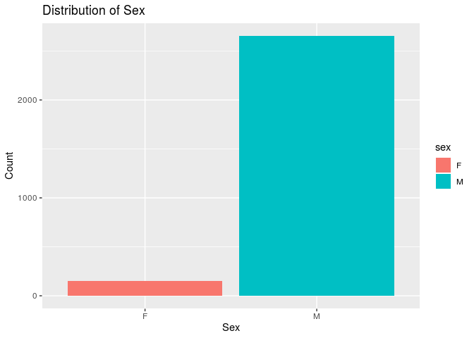

```r
ggplot(data = data, aes(x = sex, fill = sex)) +
  geom_bar()+
  labs(title = "Distribution of Sex", x = "Sex", y = "Count")
```

We can see that there is far more data for male migrants than female. While it is possible, and reasonable based on historic trends, that men are more likely to migrate, sending funds back home, it is also likely that men answered the survey as the heads of households which contained more equal numbers of women.

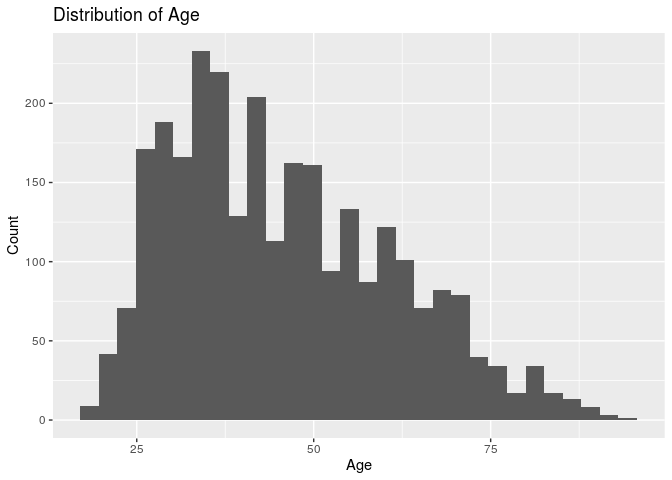

```r
ggplot(data = data, aes(x = age)) +
  geom_histogram()+
  labs(title = "Distribution of Age", x= "Age", y = "Count")
```

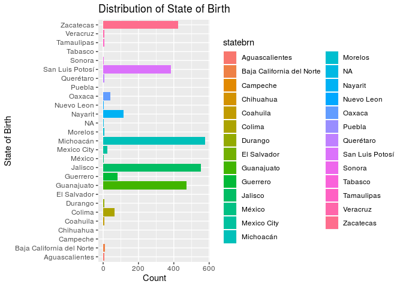

```r
ggplot(data = data, aes(x = statebrn, fill = statebrn)) +
  geom_bar() +
  coord_flip()+
  labs(title = "Distribution of State of Birth", x= "State of Birth", y = "Count")
```

```r
unique(data$statebrn)
```

```
##  [1] "Guanajuato"                "Jalisco"
##  [3] "Mexico City"               "San Luis Potosí"
##  [5] "Zacatecas"                 "Coahuila"
##  [7] "Morelos"                   "Baja California del Norte"
##  [9] "Querétaro"                 "Michoacán"
## [11] "Guerrero"                  "Durango"
## [13] "Chihuahua"                 "Nayarit"
## [15] "Sonora"                    "Aguascalientes"
## [17] "Veracruz"                  "Campeche"
## [19] "Colima"                    "Tabasco"
## [21] "México"                    "Puebla"
## [23] "Nuevo Leon"                "El Salvador"
## [25] "Oaxaca"                    "Tamaulipas"
## [27] "NA"
```

Clearly, the most common states of birth by far are Zacatecas, San Luis Potosí, Michoacán, Jalisco, and Guanajuato. These states border one another and are in the west-central part of Mexico.

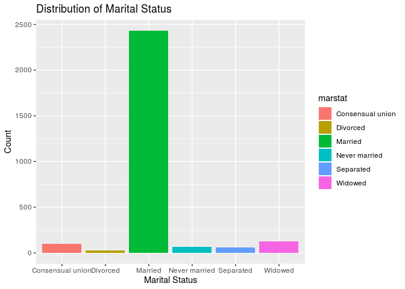

```r
ggplot(data = data, aes(x = marstat, fill = marstat)) +
  geom_bar()+ labs(title = "Distribution of Marital Status", x= "Marital Status", y = "Count")
```

The majority of those surveyed were married.

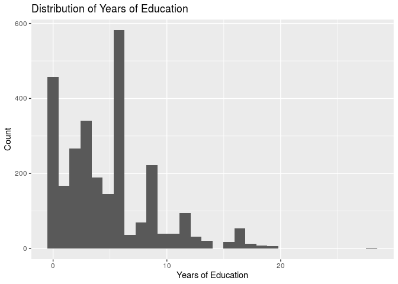

```r
ggplot(data = data, aes(x = edyrs)) +
  geom_histogram()+
  labs(title = "Distribution of Years of Education", x= "Years of Education", y = "Count")
```

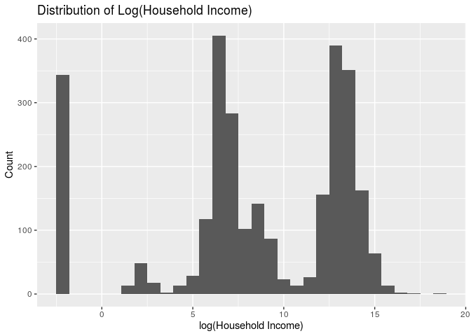

```r
ggplot(data = data, aes(x = log(hhincome))) +
  geom_histogram()+
  labs(title = "Distribution of Log(Household Income)", x= "log(Household Income)", y = "Count")
```

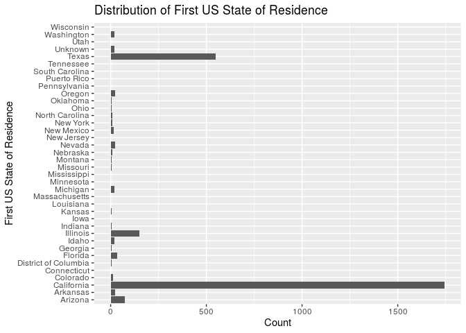

```r
ggplot(data = data, aes(x = usstate1)) +
  geom_bar() +
  coord_flip()+
  labs(title = "Distribution of First US State of Residence", x= "First US State of Residence", y = "Count")
```

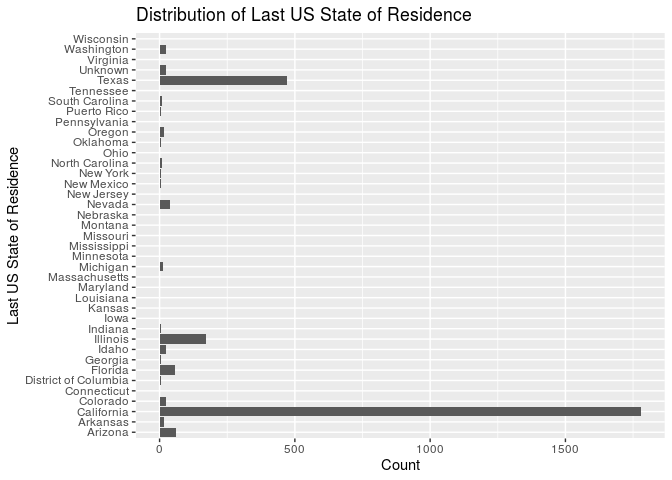

```r
ggplot(data = data, aes(x = usstatel)) +
  geom_bar() +
  coord_flip()+
  labs(title = "Distribution of Last US State of Residence", x= "Last US State of Residence", y = "Count")
```

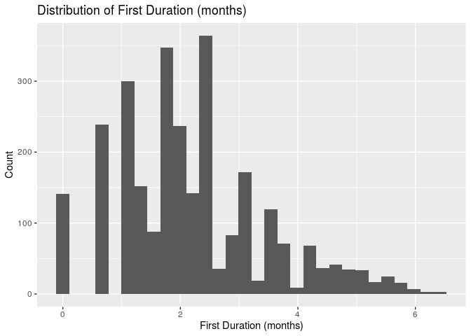

```r
ggplot(data = data, aes(x = log(usdur1))) +
  geom_histogram()+
  labs(title = "Distribution of First Duration (months)", x= "First Duration (months)", y = "Count")
```

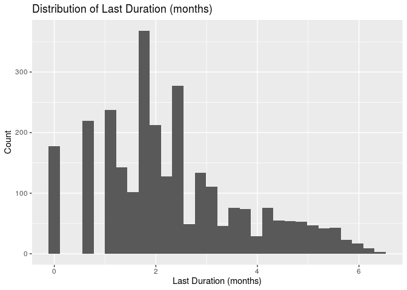

```r
ggplot(data = data, aes(x = log(usdurl))) +
  geom_histogram()+
  labs(title = "Distribution of Last Duration (months)", x= "Last Duration (months)", y = "Count")
```

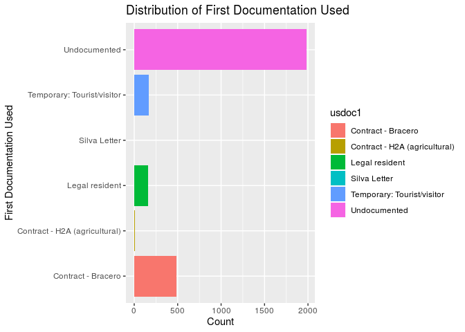

```r
ggplot(data = data, aes(x = usdoc1, fill = usdoc1)) +
  geom_bar() +
  coord_flip()+
  labs(title = "Distribution of First Documentation Used", x= "First Documentation Used", y = "Count")
```

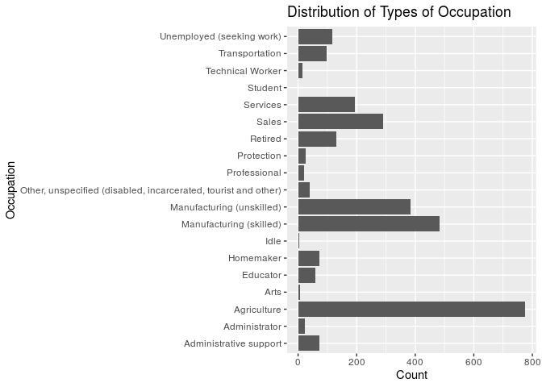

```r
ggplot(data = data, aes(x = occtype)) +
  geom_bar()+
  coord_flip()+
  labs(title = "Distribution of Types of Occupation", x= "Occupation", y = "Count")
```

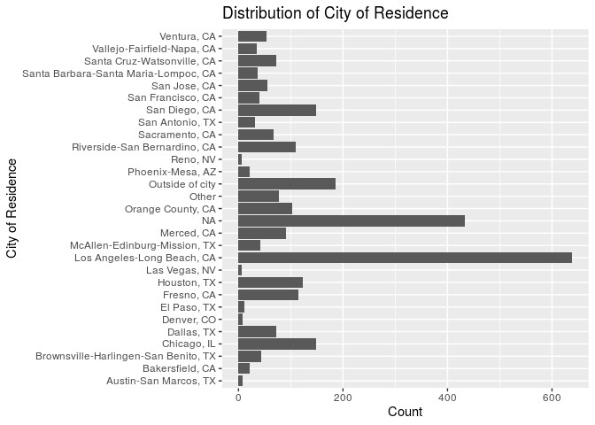

```r
ggplot(data = data, aes(x = uscity)) +
  geom_bar() +
  coord_flip()+
  labs(title = "Distribution of City of Residence", x= "City of Residence", y = "Count")
```

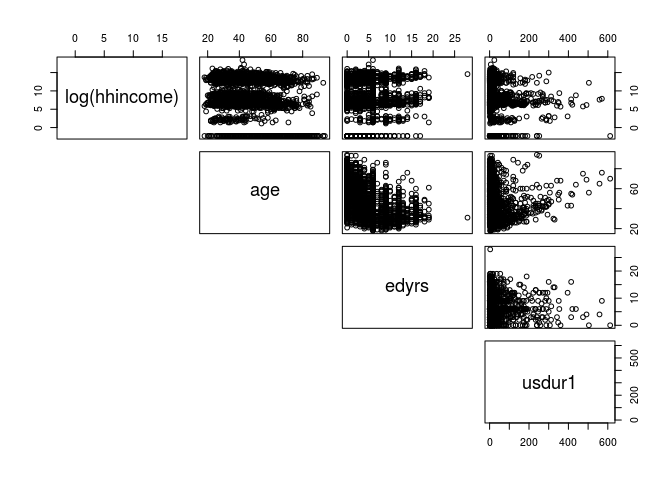

```r
pairs(log(hhincome) ~ age + edyrs + usdur1, data = data,
      lower.panel = NULL)
```

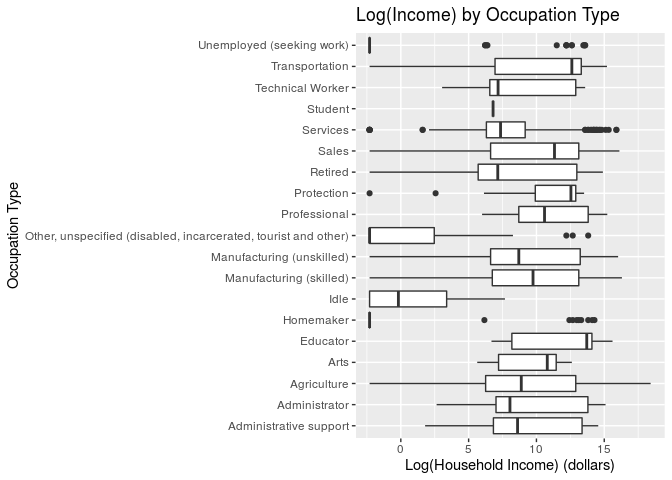

```r
ggplot(data = data, aes(x = occtype, y = log(hhincome))) +
  geom_boxplot() +
  coord_flip() +
  labs(title = "Log(Income) by Occupation Type", x = "Occupation Type", y = "Log(Household Income) (dollars)")
```

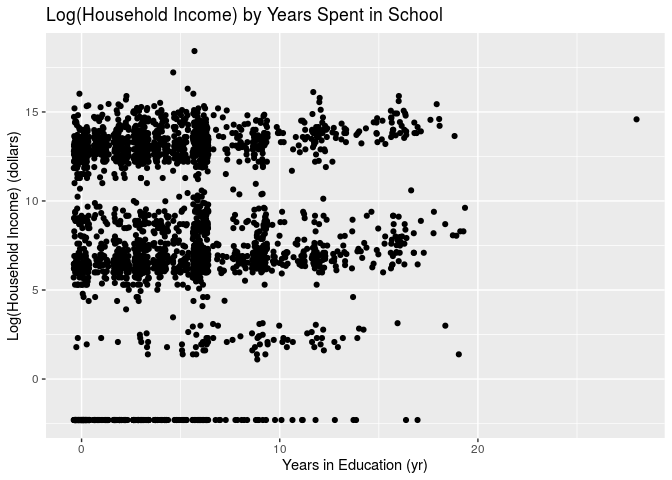

```r
ggplot(data = data, aes(x = edyrs, y = log(hhincome))) +
  geom_jitter() +
  labs(title = "Log(Household Income) by Years Spent in School", x = "Years in Education (yr)", y = "Log(Household Income) (dollars)")
```

From the scatterplot, it seems that there is no obvious relationship between years of education and log(household income). This is discouraging because we can infer that many of the immigrants are underemployed, or are not paid according to their skill and professional experience level.

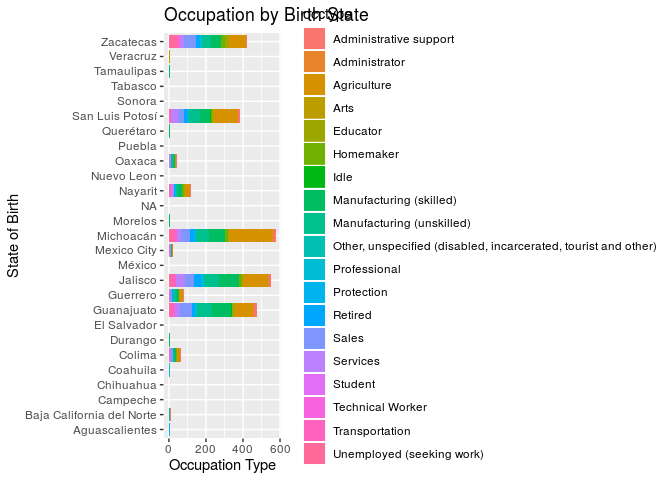

```r
ggplot(data = data, aes(x = statebrn, fill = occtype)) +
  geom_bar() +
  coord_flip() +
  labs(title = "Occupation by Birth State", x = "State of Birth", y = "Occupation Type")
```

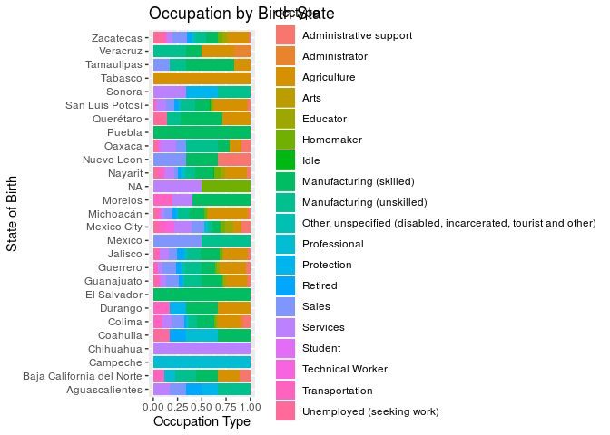

```r
ggplot(data = data, aes(x = statebrn, fill = occtype)) +
  geom_bar(position = "fill") +
  coord_flip()+
  labs(title = "Occupation by Birth State", x = "State of Birth", y = "Occupation Type")
```

It would seem possible that more migrants of a certain occupation would migrate to the US from a certain region (i.e., that the state a person is from has an effect on their occupation type, depending on the specialty types of their region, such as agriculture or manufacturing). However, no trends are immediately clear from either of these graphs- the few differences in the proportion graph (such as El Salvador as the origin of solely skilled manufacturers) are likely skewed by the fact that very few migrants in the dataset were born in those states.

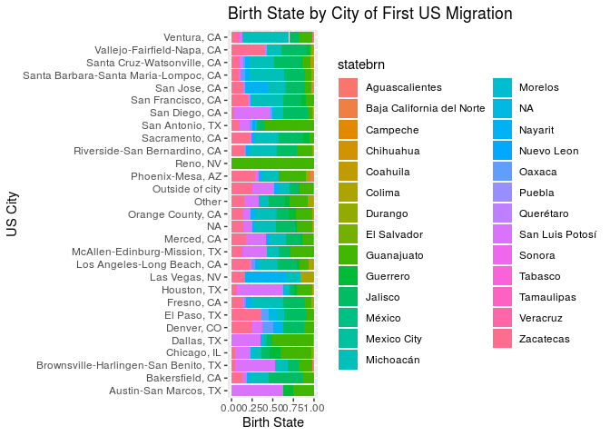

```r
ggplot(data = data, aes(x = uscity, fill = statebrn)) +
  geom_bar(position = "fill") +
  coord_flip() +
  labs(title = "Birth State by City of First US Migration", x = "US City", y = "Birth State")
```

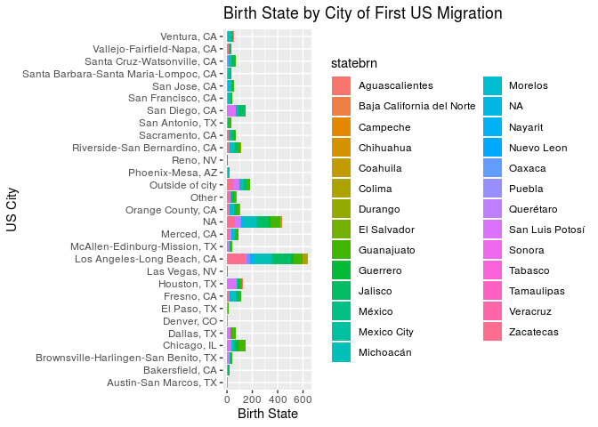

```r
ggplot(data = data, aes(x = uscity, fill = statebrn)) +
  geom_bar()+
  coord_flip()+
  labs(title = "Birth State by City of First US Migration", x = "US City", y = "Birth State")
```

If migrants born in certain states in Mexico tend to migrate to the same places in the US as other migrants from their home state, we would expect to see an effect here. It does appear that San Diego and Houston have a disproportionately low number of migrants born in Zacatecas, and there may be a higher concentration of migrants born in Colima in LA-Long Beach. This interaction might be worth further investigation.

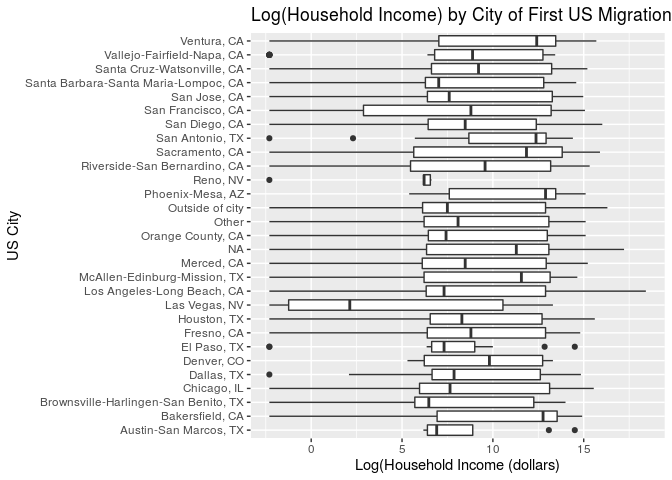

```r
ggplot(data = data, aes(x = uscity, y = log(hhincome))) +
  geom_boxplot() +
  coord_flip() +
  labs(title = "Log(Household Income) by City of First US Migration", x = "US City", y = "Log(Household Income (dollars)")
```

The city in which a migrant lives and works in the US could also have an effect on their income- most IQRs for these cities appear very similar, but Las Vegas’s median log(income) is significantly lower, although the spread is greater. It is also interesting that the IQRs appear so even city-to-city despite the difference in minimum wage laws and living expenses in various states.

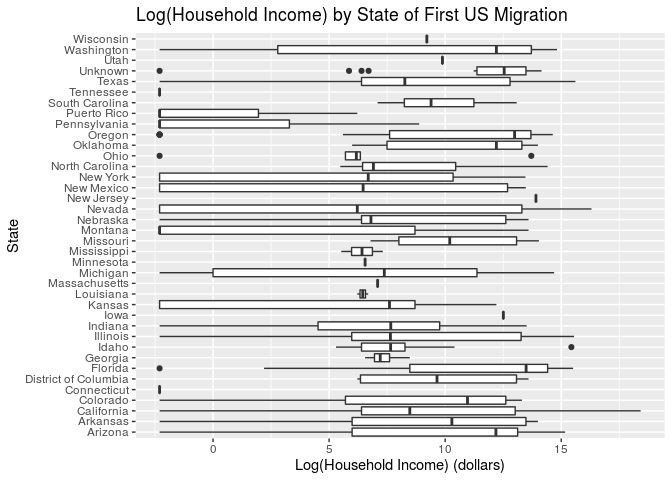

```r
ggplot(data = data, aes(x = usstate1, y = log(hhincome))) +
  geom_boxplot() +
  coord_flip() +
  labs(title = "Log(Household Income) by State of First US Migration", x = "State", y = "Log(Household Income) (dollars)")
```

The log(household income) appears to differ much more significantly by state than by city. With income in Puerto Rico and Pennsylvania noticeably lower than the other states, depending on skew due to different sample sizes in each state, this may prove an important interaction. Grouping states into regions of the US to create more evenly sized groups will aid in future analysis.

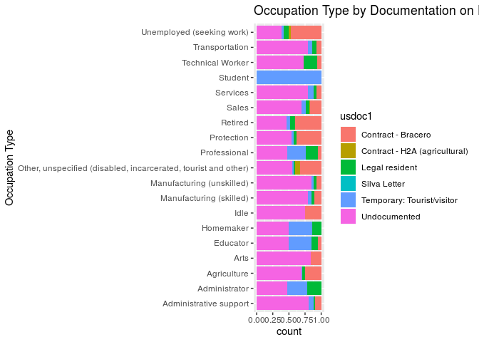

```r
ggplot(data = data, aes(x = occtype, fill = usdoc1)) +
  geom_bar(position = "fill") +
  coord_flip() +
  labs(title = "Occupation Type by Documentation on First Migration to US", x = "Occupation Type")
```

## Section 3. Regression Analysis Plan

In an effort to determine which characteristics of candidates influence their household income, we will be using a multiple linear regression model. Since our response variable is numerical with mulitple potential predictors, this is the best model at our disposal for us to use.

We will consider the potential interaction between principal occupation and number of years of school completed, since those are generally interconnected. We may also consider the interaction between documentation type and occupation type, although the effect may be insignificant.

We will select our model using AIC criteria, because since we’re dealing with people, we want to build a model that accounts for volatile human nature and the ever-changing socioeconomic and political climate that could influence someone’s household income. AIC is used when we would rather say a variable is a relevant predictor, when in reality it might not be and so in this case, we would rather err on the side of a false positive because we are dealing with a constantly fluctuating issue.

## Section 4. References

Below is a glimpse of our data:

```r
glimpse(data)
```

```
## Observations: 2,805
## Variables: 19
## $ X1       <dbl> 1, 2, 3, 4, 5, 6, 7, 8, 9, 10, 11, 12, 13, 14, 15, 16, …
## $ sex      <chr> "M", "M", "M", "M", "M", "M", "M", "M", "M", "M", "M", …
## $ relhead  <fct> 1, 1, 1, 1, 1, 1, 1, 1, 1, 1, 1, 1, 1, 1, 1, 1, 1, 1, 1…
## $ yrborn   <dbl> 1938, 1928, 1950, 1946, 1956, 1921, 1914, 1932, 1945, 1…
## $ age      <dbl> 49, 59, 37, 41, 31, 66, 73, 55, 42, 42, 51, 36, 41, 69,…
## $ statebrn <chr> "Guanajuato", "Guanajuato", "Guanajuato", "Guanajuato",…
## $ marstat  <chr> "Married", "Married", "Never married", "Married", "Marr…
## $ edyrs    <dbl> 3, 3, 6, 6, 6, 0, 0, 6, 6, 6, 3, 2, 6, 2, 0, 2, 3, 6, 3…
## $ occ      <dbl> 522, 522, 410, 522, 142, 529, 830, 719, 559, 819, 522, …
## $ hhincome <dbl> 2.50e+05, 2.00e+05, 1.44e+06, 3.00e+05, 3.00e+05, 2.00e…
## $ usstate1 <chr> "Illinois", "California", "California", "Colorado", "Ca…
## $ usstatel <chr> "Illinois", "California", "Illinois", "Unknown", "Calif…
## $ usplace1 <dbl> 1600, 7360, 7320, 2080, 4480, 7360, 9999, 6920, 7320, 9…
## $ usplacel <dbl> 1600, 4480, 1600, 9999, 4480, 7360, 9999, 2080, 7320, 9…
## $ usdur1   <dbl> 12, 12, 36, 6, 12, 24, 6, 6, 6, 12, 8, 12, 12, 4, 24, 3…
## $ usdurl   <dbl> 6, 12, 48, 6, 12, 24, 6, 6, 6, 12, 4, 8, 6, 14, 24, 24,…
## $ usdoc1   <chr> "Undocumented", "Contract - Bracero", "Undocumented", "…
## $ occtype  <chr> "Manufacturing (skilled)", "Manufacturing (skilled)", "…
## $ uscity   <chr> "Chicago, IL", "San Francisco, CA", "San Diego, CA", "D…
```

```r
write_csv(data, "/cloud/project/03-regression-analysis/data.csv")
```

Sources:

Statistic used in Introduction: RPC. (January 31, 2019). Number of refugee admissions in the U.S. from the fiscal year of 1990 to the fiscal year of 2018
$$Graph$$
. In Statista. Retrieved October 29, 2019, from https://www-statista-com.proxy.lib.duke.edu/statistics/200061/number-of-refugees-arriving-in-the-us/

Dataset obtained at https://mmp.opr.princeton.edu/home-en.aspx This data is under the following confidentiality terms: -Only for use for research and/or educational purposes -Do not try to identify any individual, household or migrant community -Do not give access to the MMP data to anyone who does not agree to respect these confidentiality terms.